# 統計データ解析

第9講 判別分析 - 分析の評価

Published

December 6, 2024

## 準備

以下で利用する共通パッケージを読み込む．

```r
library(conflicted) # 関数名の衝突を警告
conflicts_prefer(   # 優先的に使う関数を指定
    dplyr::filter(),
    dplyr::select(),
    dplyr::lag(),
    yardstick::spec(),
    yardstick::precision(),
    yardstick::recall(),
    )
library(tidyverse)
library(MASS)
library(broom)      # 解析結果を tibble 形式に集約
library(tidymodels)
```

## 判別結果の評価

### 問題

前回と同様に東京の気候データの線形判別を行い，以下を確認しなさい．

- 9月と10月の気温と湿度のデータを抽出する．

  ```r
  tw_data <- read_csv("data/tokyo_weather.csv")
  tw_subset  <- tw_data |>
      filter(month %in% c(9,10)) |>
      select(temp, humid, month) |>
      mutate(month = as_factor(month)) # 月を因子化
  ```

- 線形判別関数を構成する．

  ```r
  tw_lda <- lda(formula = month ~ temp + humid, data = tw_subset)
  ```

- 混同行列を用いて構成した判別関数の評価を行う．[^1]

  ```r
  tw_lda_fitted <- predict(tw_lda)              # あてはめ値を求める
  tw_subset |>
      mutate(fitted = tw_lda_fitted[["class"]]) # あてはめ値を加えたデータフレーム
  ```

- ROC曲線を描画しAUCを求める．[^2]

  ```r
  tw_subset |>
      bind_cols(tw_lda_fitted[["posterior"]])
  ```

<sup>1</sup> 関数 `lda()` の返値の `class` は vector 型なので，関数 `mutate()` を用いてデータフレームの列として加えることができる．

<sup>2</sup> 関数 `lda()` の返値の `posterior` は matrix 型なので，関数 `bind_cols()` を用いてデータフレームとして結合することができる．

### 解答例

データを整理する．

```r
tw_data <- read_csv("data/tokyo_weather.csv")
tw_subset  <- tw_data |>
    filter(month %in% c(9,10)) |> # 9,10月のデータ
    select(temp, humid, month) |> # 気温・湿度・月を選択
    mutate(month = as_factor(month)) # 月を因子化
```

判別関数を作成する．

```r
tw_lda <- lda(formula = month ~ temp + humid,
              data = tw_subset)
```

混同行列を用いて判別結果を評価する．

```r
tw_lda_fitted <- predict(tw_lda)
tw_lda_cm <- tw_subset |>
    bind_cols(fitted = tw_lda_fitted[["class"]]) |> # 関数 mutate() でも良い
    conf_mat(truth = month, estimate = fitted)
tw_lda_cm # 簡便な表示
```

```
          Truth
Prediction  9 10
        9  28  1
        10  2 30
```

```r
summary(tw_lda_cm) # 詳細な表示
```

```
# A tibble: 13 × 3
   .metric              .estimator .estimate
   <chr>                <chr>          <dbl>
 1 accuracy             binary         0.951
 2 kap                  binary         0.902
 3 sens                 binary         0.933
 4 spec                 binary         0.968
 5 ppv                  binary         0.966
 6 npv                  binary         0.938
 7 mcc                  binary         0.902
 8 j_index              binary         0.901
 9 bal_accuracy         binary         0.951
10 detection_prevalence binary         0.475
11 precision            binary         0.966
12 recall               binary         0.933
13 f_meas               binary         0.949
```

関数 `ggplot2::autoplot()` を用いて視覚化する．

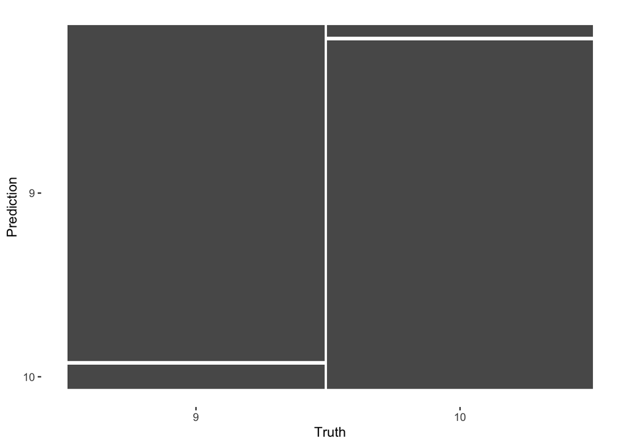

```r
autoplot(tw_lda_cm, type = "mosaic")  # モザイクプロット
```

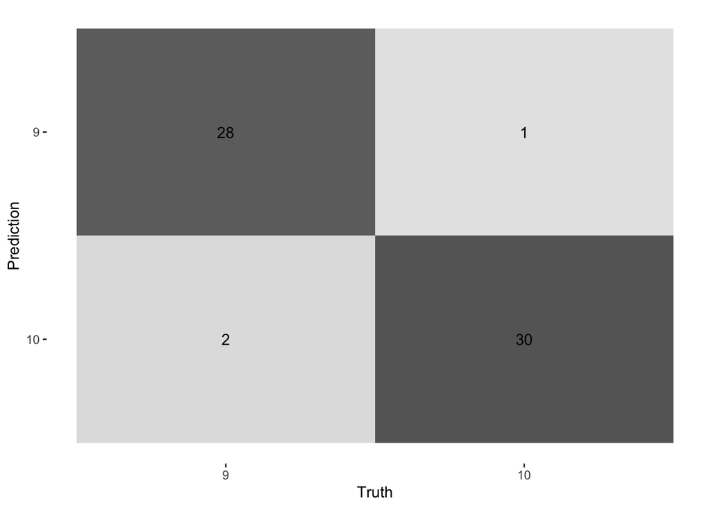

```r
autoplot(tw_lda_cm, type = "heatmap") # 行列表示
```

ROC曲線の描画を行う．

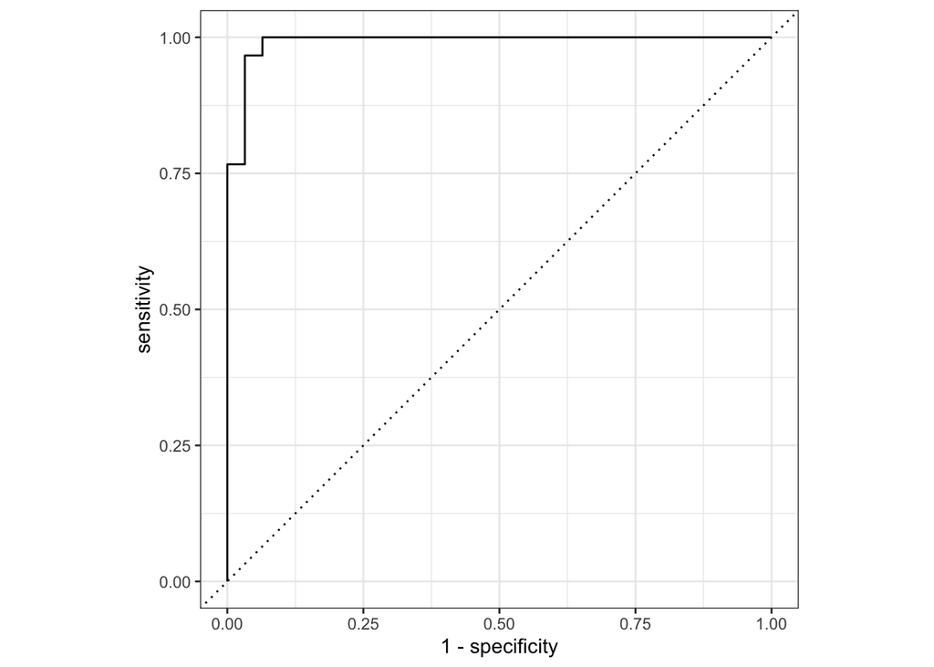

```r
tw_subset |>
    bind_cols(tw_lda_fitted[["posterior"]]) |>
    roc_curve(truth = month, `9`) |> # 9月(`9`列)への判別を陽性とする
    autoplot()
```

AUCを計算する．

```r
tw_subset |>
    bind_cols(tw_lda_fitted[["posterior"]]) |>
    roc_auc(truth = month, `9`)
```

```
# A tibble: 1 × 3
  .metric .estimator .estimate
  <chr>   <chr>          <dbl>
1 roc_auc binary         0.991
```

以下は12ヶ月分のデータを用いた例で，これを参考に説明変数は適宜選択して検討してほしい．

データを整理する．

```r
tw_subset12  <- tw_data |>
    select(temp, solar, wind, humid, month) |>
    mutate(month = as_factor(month))
```

`Jan`, `Feb` などの文字を扱いたい場合は関数 `as_factor()` を用いるかわりに `month(month, label = TRUE)` とすればよい． その場合，列名の指定なども ‘`Jan`:`Dec`’ などと変わるので注意する．

判別関数を作成する．

```r
tw_lda12 <- lda(month ~ ., # 右辺の . は month 以外の全てを説明変数として指定
                data = tw_subset12)
```

判別結果を評価する．

```r
tw_lda12_fitted <- predict(tw_lda12)
tw_lda12_cm <- tw_subset12 |>
    bind_cols(fitted = tw_lda12_fitted[["class"]]) |>
    conf_mat(truth = month, estimate = fitted)
tw_lda12_cm # 表示
```

```
          Truth
Prediction  1  2  3  4  5  6  7  8  9 10 11 12
        1  23  9  0  0  0  0  0  0  0  0  0  4
        2   4 11  1  0  0  0  0  0  0  0  0  1
        3   1  2 17  5  2  0  0  0  0  2  4  3
        4   0  0  4 11  3  0  0  0  0  0  0  0
        5   0  0  3  6 18  3  0  0  0  0  0  0
        6   0  0  0  0  4 19  3  0  3  1  1  0
        7   0  0  0  0  1  3 18  7  5  0  0  0
        8   0  0  0  0  0  0  2 18  6  0  0  0
        9   0  0  0  0  0  3  8  6 15  1  1  0
        10  0  0  0  1  2  2  0  0  1 25  8  1
        11  0  0  4  7  1  0  0  0  0  2  7  4
        12  3  6  2  0  0  0  0  0  0  0  9 18
```

```r
summary(tw_lda12_cm) # 詳細表示
```

[output not shown]

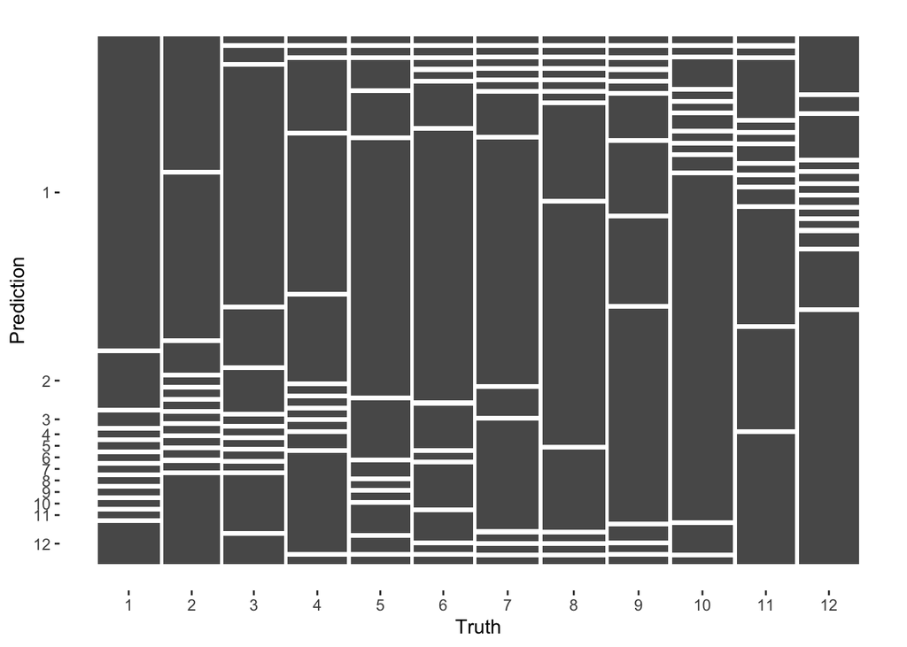

```r
autoplot(tw_lda12_cm, type = "mosaic") # モザイクプロット
```

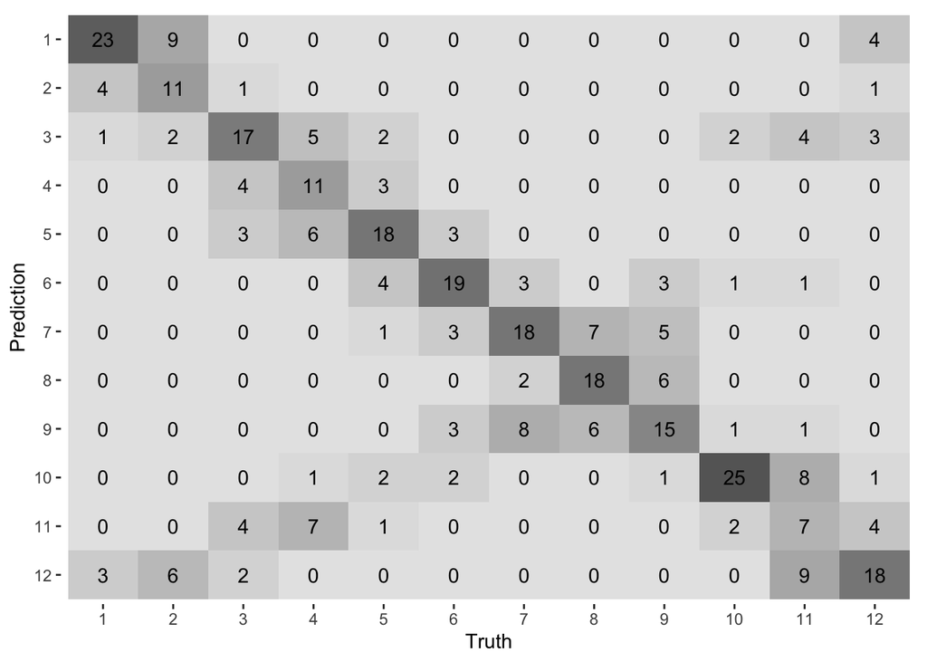

```r
autoplot(tw_lda12_cm, type = "heatmap") # 行列表示
```

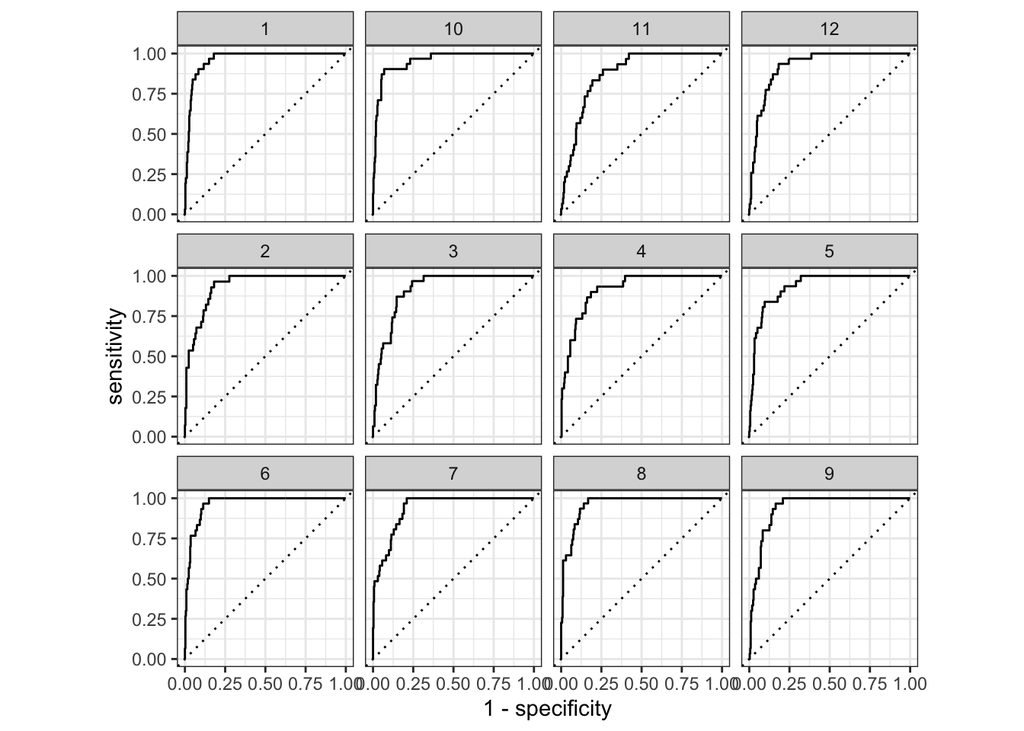

```r
tw_subset12 |>
    bind_cols(tw_lda12_fitted[["posterior"]]) |>
    roc_curve(truth = month, `1`:`12`) |>
    autoplot()
```

```r
tw_subset12 |>
    bind_cols(tw_lda12_fitted[["posterior"]]) |>
    roc_auc(truth = month, `1`:`12`)
```

```
# A tibble: 1 × 3
  .metric .estimator .estimate
  <chr>   <chr>          <dbl>
1 roc_auc hand_till      0.935
```

## 訓練・試験データによる評価

### 問題

Wine Quality Data Set を用いて，以下を確認しなさい．

- 8:2の比率で訓練データと試験データに分割する ．

  ```r
  wq_split <-
      initial_split(wq_data, prop = 0.8, strata = grade)
  training(wq_split))
  testing(wq_split)
  ```

- 訓練データを用いて線形・2次判別関数を構成する．
- 訓練データを用いて評価を行う．
- 試験データを用いて評価を行う．

### 解答例

データを整理する．

```r
wq_data <-
    read_delim("https://archive.ics.uci.edu/ml/machine-learning-databases/wine-quality/winequality-red.csv",
               delim = ";") |>
    mutate(grade = factor(case_when( # quality を A,B,C,D に割り当てる
               quality >= 7 ~ "A",
               quality >= 6 ~ "B",
               quality >= 5 ~ "C",
               .default = "D"
           )))
```

訓練・試験のためにデータを分割する．

```r
set.seed(987987) # 適宜シード値は設定する
wq_split <- initial_split(wq_data, prop = 0.8,
                          strata = grade)
```

オプション `strata` (層別) を指定すると分割したデータの `grade` の比率が保たれる．

線形および2次判別関数を作成する．ただし，`grade` のもとになっている `quality` は除く．

```r
wq_formula <- grade ~ . - quality
wq_lda <- lda(formula = wq_formula, data = training(wq_split))
wq_qda <- qda(formula = wq_formula, data = training(wq_split))
```

訓練データを用いて判別結果を評価する．

```r
wq_lda_train_cm <- training(wq_split) |>
    bind_cols(fitted = predict(wq_lda)[["class"]]) |>
    conf_mat(truth = grade, estimate = fitted)
summary(wq_lda_train_cm) # 線形判別の評価
```

```
# A tibble: 13 × 3
   .metric              .estimator .estimate
   <chr>                <chr>          <dbl>
 1 accuracy             multiclass     0.615
 2 kap                  multiclass     0.380
 3 sens                 macro          0.484
 4 spec                 macro          0.844
 5 ppv                  macro          0.534
 6 npv                  macro          0.848
 7 mcc                  multiclass     0.381
 8 j_index              macro          0.328
 9 bal_accuracy         macro          0.664
10 detection_prevalence macro          0.25
11 precision            macro          0.534
12 recall               macro          0.484
13 f_meas               macro          0.501
```

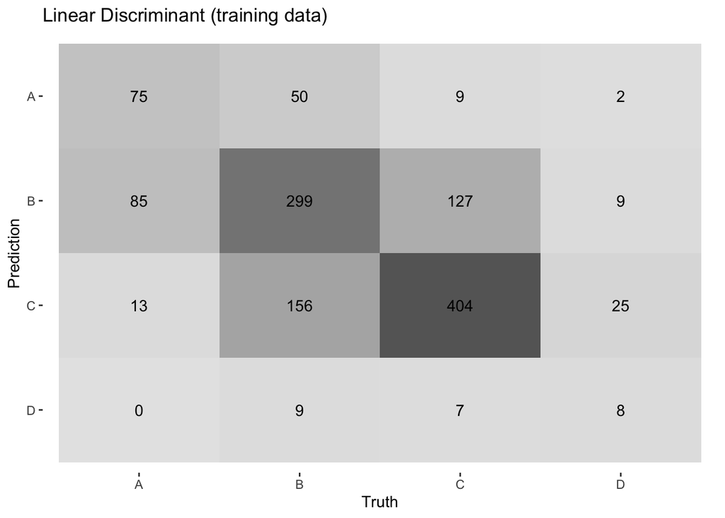

```r
autoplot(wq_lda_train_cm, type = "heatmap") +
    labs(title = "Linear Discriminant (training data)")
```

```r
wq_qda_train_cm <- training(wq_split) |>
    bind_cols(fitted = predict(wq_qda)[["class"]]) |>
    conf_mat(truth = grade, estimate = fitted)
summary(wq_qda_train_cm) # 2次判別の評価
```

```
# A tibble: 13 × 3
   .metric              .estimator .estimate
   <chr>                <chr>          <dbl>
 1 accuracy             multiclass     0.626
 2 kap                  multiclass     0.411
 3 sens                 macro          0.549
 4 spec                 macro          0.852
 5 ppv                  macro          0.568
 6 npv                  macro          0.852
 7 mcc                  multiclass     0.411
 8 j_index              macro          0.401
 9 bal_accuracy         macro          0.700
10 detection_prevalence macro          0.25
11 precision            macro          0.568
12 recall               macro          0.549
13 f_meas               macro          0.556
```

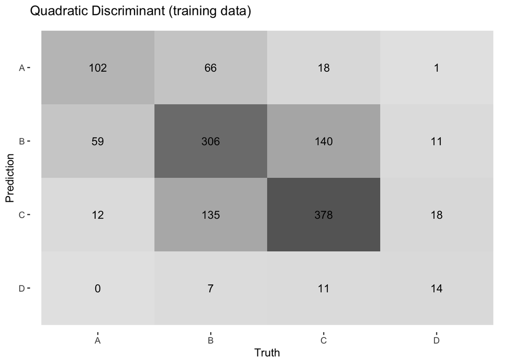

```r
autoplot(wq_qda_train_cm, type = "heatmap") +
    labs(title = "Quadratic Discriminant (training data)")
```

試験データを用いて判別結果を評価する．

```r
wq_lda_test_cm <- testing(wq_split) |>
    bind_cols(fitted = predict(wq_lda,
                               newdata = testing(wq_split))[["class"]]) |>
    conf_mat(truth = grade, estimate = fitted)
summary(wq_lda_test_cm) # 線形判別の評価
```

```
# A tibble: 13 × 3
   .metric              .estimator .estimate
   <chr>                <chr>          <dbl>
 1 accuracy             multiclass     0.607
 2 kap                  multiclass     0.379
 3 sens                 macro          0.485
 4 spec                 macro          0.843
 5 ppv                  macro          0.569
 6 npv                  macro          0.847
 7 mcc                  multiclass     0.382
 8 j_index              macro          0.329
 9 bal_accuracy         macro          0.664
10 detection_prevalence macro          0.25
11 precision            macro          0.569
12 recall               macro          0.485
13 f_meas               macro          0.508
```

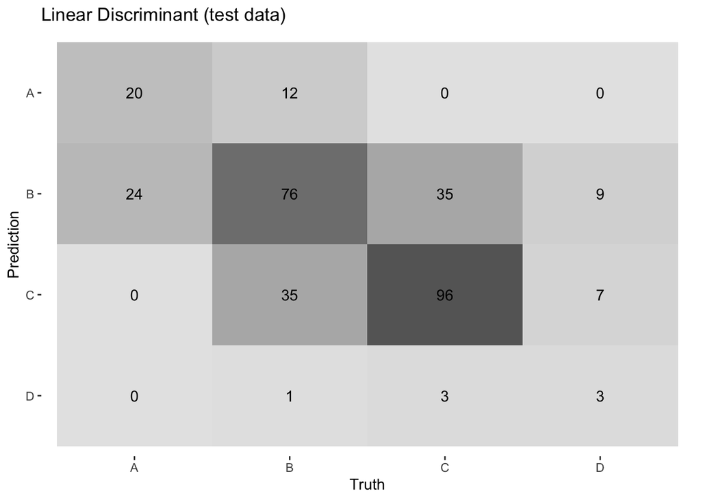

```r
autoplot(wq_lda_test_cm, type = "heatmap") +
    labs(title = "Linear Discriminant (test data)")
```

```r
wq_qda_test_cm <- testing(wq_split) |>
    bind_cols(fitted = predict(wq_qda,
                               newdata = testing(wq_split))[["class"]]) |>
    conf_mat(truth = grade, estimate = fitted)
summary(wq_qda_test_cm) # 2次判別の評価
```

```
# A tibble: 13 × 3
   .metric              .estimator .estimate
   <chr>                <chr>          <dbl>
 1 accuracy             multiclass     0.604
 2 kap                  multiclass     0.383
 3 sens                 macro          0.502
 4 spec                 macro          0.844
 5 ppv                  macro          0.541
 6 npv                  macro          0.847
 7 mcc                  multiclass     0.383
 8 j_index              macro          0.346
 9 bal_accuracy         macro          0.673
10 detection_prevalence macro          0.25
11 precision            macro          0.541
12 recall               macro          0.502
13 f_meas               macro          0.513
```

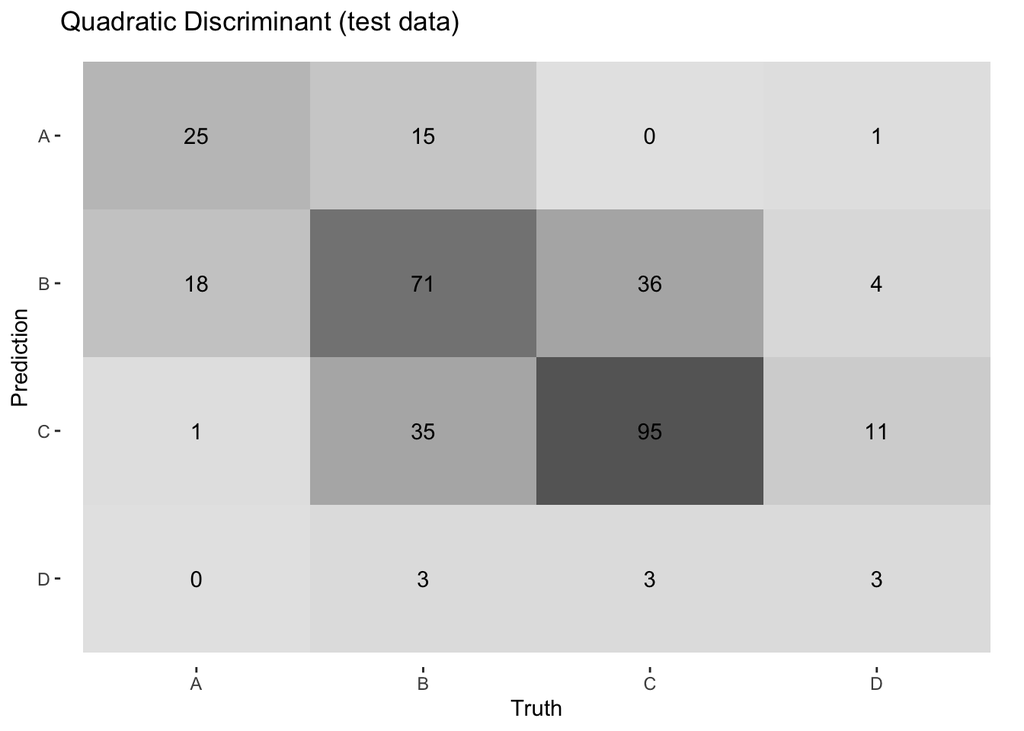

```r
autoplot(wq_qda_test_cm, type = "heatmap") +
    labs(title = "Quadratic Discriminant (test data)")
```

## LOO交叉検証法による予測誤差の評価

### 問題

データセット `MASS::biopsy` を用いて2次判別の分析を行いなさい．

```r
bio_data <- as_tibble(biopsy) |>
    na.omit() |> # NA を除く
    select(-ID)  # IDを除く
```

- 全てのデータを用いて訓練誤差を評価する．
- LOO交叉検証法を用いて予測誤差を評価する．

  ```r
  bio_qda_loo <- qda(class ~ ., data = bio_data, CV = TRUE)
  ```

### 解答例

データを整理する．

```r
bio_data <- as_tibble(biopsy) |>
    na.omit() |> # NA を除く
    select(-ID)  # IDを除く
```

散布図で項目間の関係を確認する．

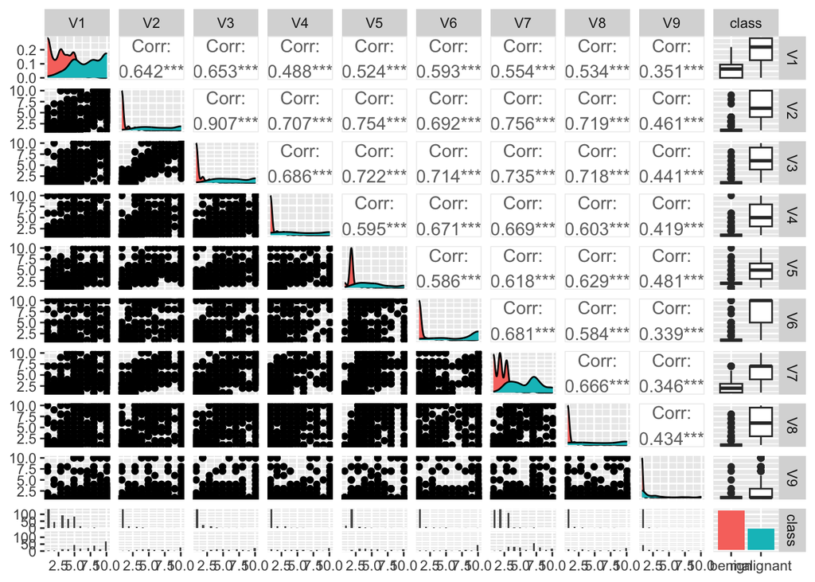

```r
bio_data |>
    GGally::ggpairs(diag = list(mapping = aes(colour = class),
                      lower = list(mapping = aes(colour = class))))
```

以下は2次判別の LOO CV による評価の例である． 線形判別も同様に行うことができる．

```r
bio_formula <- class ~ .
bio_qda <- qda(formula = bio_formula, data = bio_data)
bio_qda_loo <- qda(formula = bio_formula, data = bio_data, CV = TRUE)
```

訓練誤差での評価を確認し，可視化する．

```r
bio_qda_cm <- bio_data |>
    bind_cols(fitted = predict(bio_qda)[["class"]]) |>
    conf_mat(truth = class, estimate = fitted)
summary(bio_qda_cm) # 2次判別によるあてはめ値の評価(訓練誤差)
```

```
# A tibble: 13 × 3
   .metric              .estimator .estimate
   <chr>                <chr>          <dbl>
 1 accuracy             binary         0.959
 2 kap                  binary         0.911
 3 sens                 binary         0.950
 4 spec                 binary         0.975
 5 ppv                  binary         0.986
 6 npv                  binary         0.914
 7 mcc                  binary         0.912
 8 j_index              binary         0.925
 9 bal_accuracy         binary         0.963
10 detection_prevalence binary         0.627
11 precision            binary         0.986
12 recall               binary         0.950
13 f_meas               binary         0.968
```

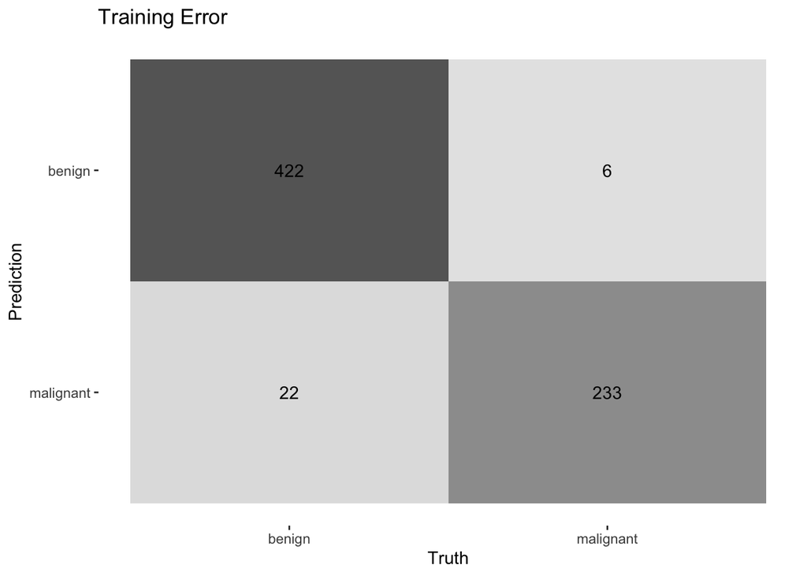

```r
autoplot(bio_qda_cm, type = "heatmap") +
    labs(title = "Training Error")
```

LOO CV での評価を確認し，可視化する．

```r
bio_qda_loo_cm <- bio_data |>
    bind_cols(fitted = bio_qda_loo[["class"]]) |>
    conf_mat(truth = class, estimate = fitted)
summary(bio_qda_loo_cm) # LOO CVによる予測の評価(予測誤差)
```

```
# A tibble: 13 × 3
   .metric              .estimator .estimate
   <chr>                <chr>          <dbl>
 1 accuracy             binary         0.950
 2 kap                  binary         0.893
 3 sens                 binary         0.937
 4 spec                 binary         0.975
 5 ppv                  binary         0.986
 6 npv                  binary         0.893
 7 mcc                  binary         0.895
 8 j_index              binary         0.912
 9 bal_accuracy         binary         0.956
10 detection_prevalence binary         0.618
11 precision            binary         0.986
12 recall               binary         0.937
13 f_meas               binary         0.961
```

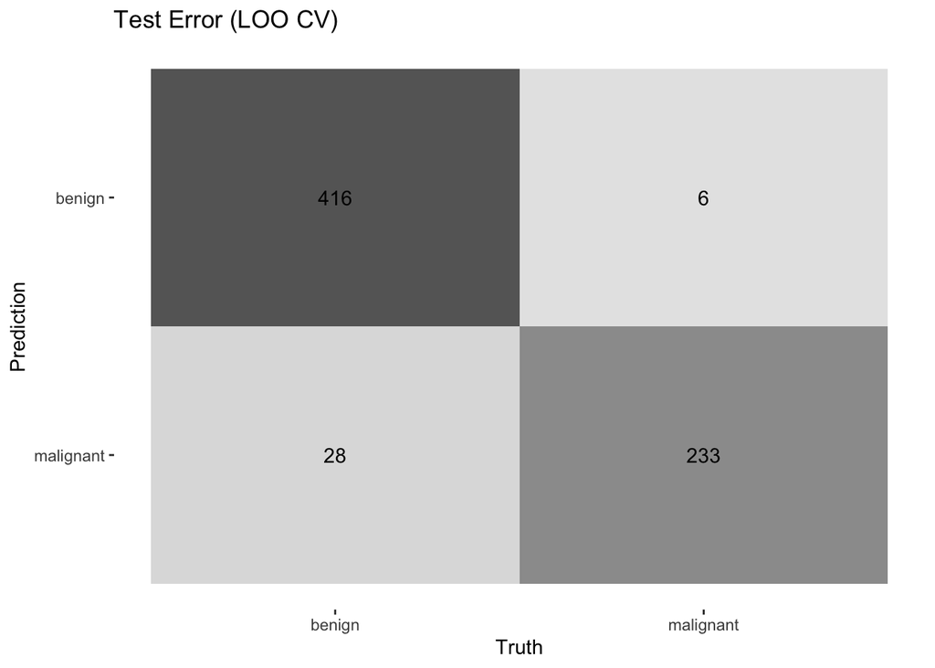

```r
autoplot(bio_qda_loo_cm, type = "heatmap") +
    labs(title = "Test Error (LOO CV)")
```

あてはめ値による評価は LOO CV より若干良くなっており，あてはめ値では精度を過剰に評価する可能性があることが示唆される．

## k-重交叉検証法による予測誤差の評価

### 問題

Wine Quality Data Set を用いて 線形判別と2次判別の分析を行いなさい．

- LOO交叉検証法を用いて予測誤差を評価する．

  ```r
  wq_lda_loo <- lda(formula = wq_formula, data = training(wq_split), CV = TRUE)
  wq_qda_loo <- qda(formula = wq_formula, data = training(wq_split), CV = TRUE)
  ```

- k-重交叉検証法を用いて予測誤差を評価する．

### 解答例

前の問題で既に整理してある `wq_data/wq_split` を用いる． `wq_lda` と比較する．

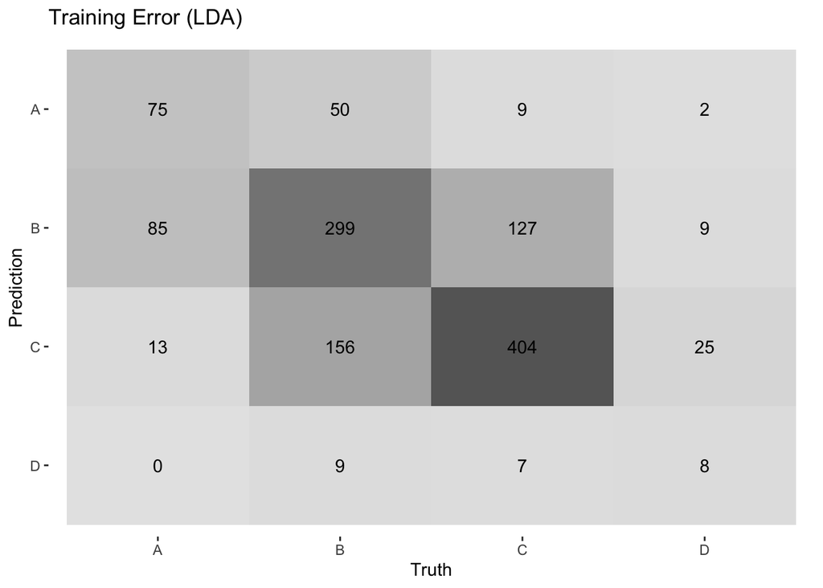

```r
wq_lda_loo <- lda(formula = wq_formula, data = training(wq_split),
                  CV = TRUE)
training(wq_split) |> # 訓練誤差による評価
    bind_cols(fitted = predict(wq_lda)[["class"]]) |>
    conf_mat(truth = grade, estimate = fitted) |>
    autoplot(type = "heatmap") +
    labs(title = "Training Error (LDA)")
```

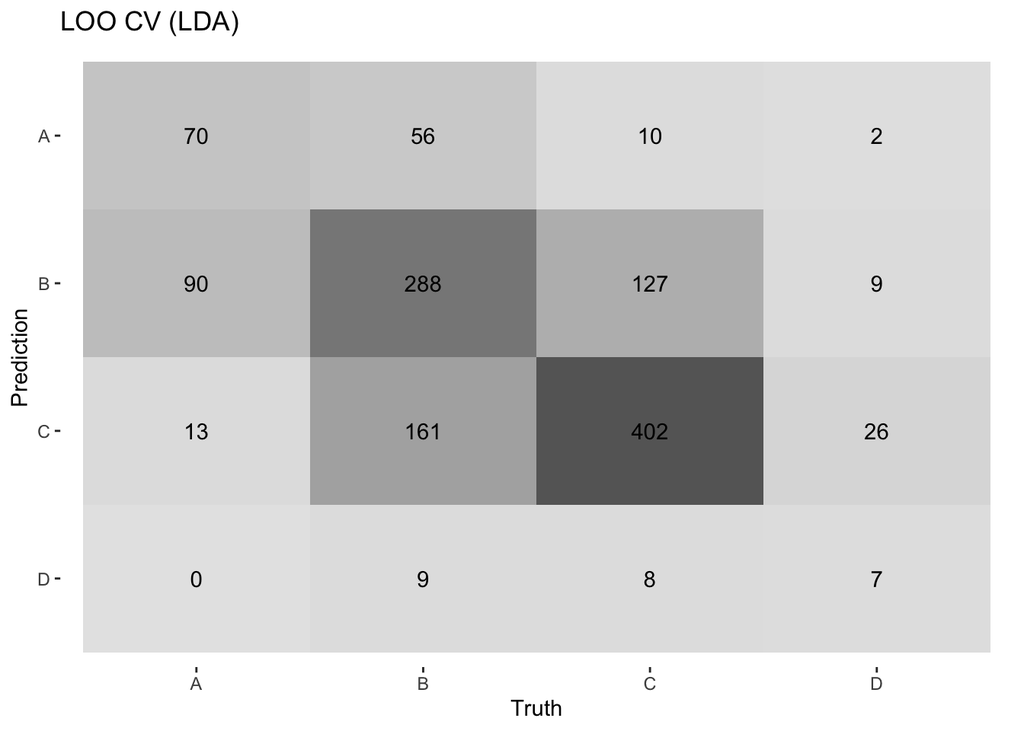

```r
wq_lda_loo_cm <- training(wq_split) |> # LOO CV 予測誤差による評価
    bind_cols(fitted = wq_lda_loo[["class"]]) |>
    conf_mat(truth = grade, estimate = fitted)
wq_lda_loo_cm |> autoplot(type = "heatmap") +
    labs(title = "LOO CV (LDA)")
```

線形判別の過学習は微小であることがわかる．

2次判別の LOO CV を `wq_qda` と比較する．

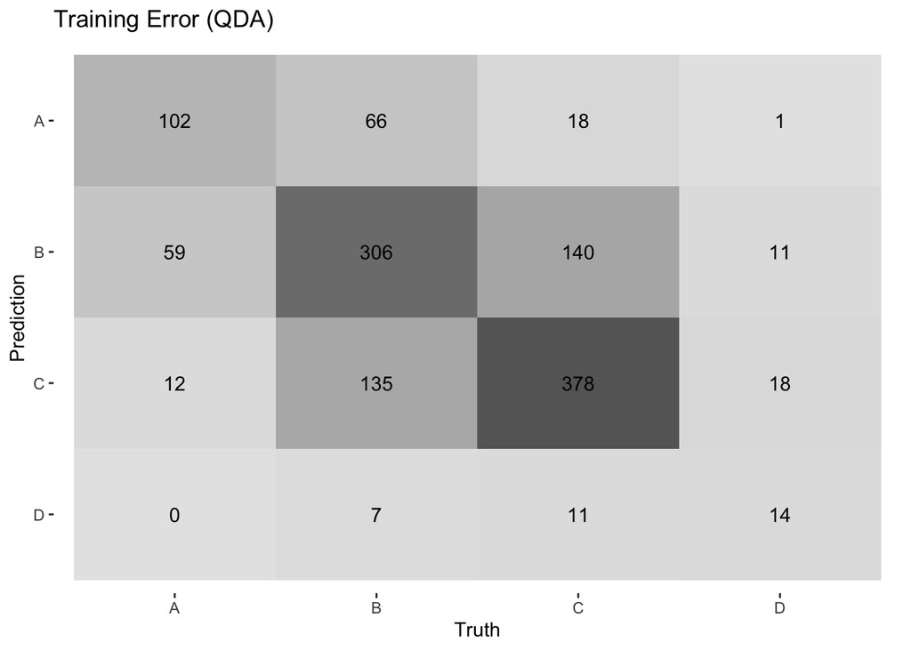

```r
wq_qda_loo <- qda(formula = wq_formula, data = training(wq_split),
                  CV = TRUE)
training(wq_split) |> # 訓練誤差による評価
    bind_cols(fitted = predict(wq_qda)[["class"]]) |>
    conf_mat(truth = grade, estimate = fitted) |>
    autoplot(type = "heatmap") +
    labs(title = "Training Error (QDA)")
```

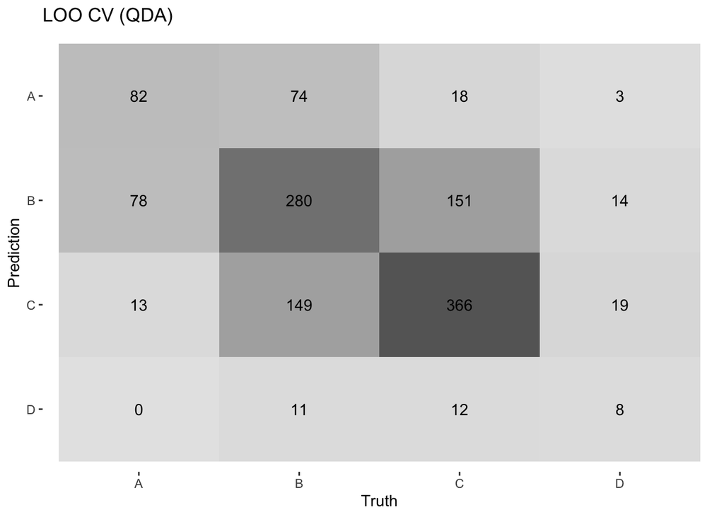

```r
wq_qda_loo_cm <- training(wq_split) |> # LOO CV 予測誤差による評価
    bind_cols(fitted = wq_qda_loo[["class"]]) |>
    conf_mat(truth = grade, estimate = fitted)
wq_qda_loo_cm |> autoplot(type = "heatmap") +
    labs(title = "LOO CV (QDA)")
```

2次判別は若干過学習していることが示唆される．

LOO CV により線形・2次判別の予測誤差を比較する．

```r
summary(wq_lda_loo_cm) # 線形
```

```
# A tibble: 13 × 3
   .metric              .estimator .estimate
   <chr>                <chr>          <dbl>
 1 accuracy             multiclass     0.600
 2 kap                  multiclass     0.357
 3 sens                 macro          0.465
 4 spec                 macro          0.839
 5 ppv                  macro          0.507
 6 npv                  macro          0.842
 7 mcc                  multiclass     0.357
 8 j_index              macro          0.304
 9 bal_accuracy         macro          0.652
10 detection_prevalence macro          0.25
11 precision            macro          0.507
12 recall               macro          0.465
13 f_meas               macro          0.479
```

```r
summary(wq_qda_loo_cm) # 2次
```

```
# A tibble: 13 × 3
   .metric              .estimator .estimate
   <chr>                <chr>          <dbl>
 1 accuracy             multiclass     0.576
 2 kap                  multiclass     0.330
 3 sens                 macro          0.467
 4 spec                 macro          0.832
 5 ppv                  macro          0.481
 6 npv                  macro          0.833
 7 mcc                  multiclass     0.330
 8 j_index              macro          0.300
 9 bal_accuracy         macro          0.650
10 detection_prevalence macro          0.25
11 precision            macro          0.481
12 recall               macro          0.467
13 f_meas               macro          0.473
```

予測誤差の観点からは線形判別の方が良さそうであることが伺える．

`package::tidymodels` を用いた k-重交叉検証は以下のようになる．

まず `lda/qda` を tidymodels 用に宣言する．

```r
library(discrim) # 以下の判別モデルを設定するために必要
tidy_qda <- discrim_quad() |> set_engine("MASS") |> set_mode("classification")
tidy_lda <- discrim_linear() |> set_engine("MASS") |> set_mode("classification")
```

交叉検証用にデータ分割を行う．

```r
wq_folds <- vfold_cv(training(wq_split),
                     v = 10) # 10-fold を指定 (既定値)
```

評価指標を設定する．

```r
wq_metrics <- metric_set(accuracy, # 精度
                         sens, # 感度 (真陽性率)
                         spec, # 特異度 (真陰性率)
                         precision, # 適合率
                         recall, # 再現率(sensと同じ)
                         roc_auc, # AUC
                         kap, # kappa
                         f_meas) # f値
```

共通の処理を定義する．

```r
wq_workflow <- workflow() |>
    add_formula(wq_formula)
```

線形判別を行い，評価する．

```r
wq_lda_cv <- wq_workflow |>
    add_model(tidy_lda) |>
    fit_resamples(resamples = wq_folds,
                  metrics = wq_metrics)
wq_lda_cv |> collect_metrics()
```

```
# A tibble: 8 × 6
  .metric   .estimator  mean     n std_err .config
  <chr>     <chr>      <dbl> <int>   <dbl> <chr>
1 accuracy  multiclass 0.597    10 0.00753 Preprocessor1_Model1
2 f_meas    macro      0.467    10 0.0221  Preprocessor1_Model1
3 kap       multiclass 0.349    10 0.0130  Preprocessor1_Model1
4 precision macro      0.511    10 0.0339  Preprocessor1_Model1
5 recall    macro      0.456    10 0.0187  Preprocessor1_Model1
6 roc_auc   hand_till  0.784    10 0.0109  Preprocessor1_Model1
7 sens      macro      0.456    10 0.0187  Preprocessor1_Model1
8 spec      macro      0.837    10 0.00291 Preprocessor1_Model1
```

2次判別を行い，評価する．

```r
wq_qda_cv <- wq_workflow |>
    add_model(tidy_qda) |>
    fit_resamples(resamples = wq_folds,
                  metrics = wq_metrics)
wq_qda_cv |> collect_metrics()
```

```
# A tibble: 8 × 6
  .metric   .estimator  mean     n std_err .config
  <chr>     <chr>      <dbl> <int>   <dbl> <chr>
1 accuracy  multiclass 0.568    10 0.00958 Preprocessor1_Model1
2 f_meas    macro      0.445    10 0.0217  Preprocessor1_Model1
3 kap       multiclass 0.317    10 0.0171  Preprocessor1_Model1
4 precision macro      0.460    10 0.0256  Preprocessor1_Model1
5 recall    macro      0.447    10 0.0201  Preprocessor1_Model1
6 roc_auc   hand_till  0.732    10 0.0192  Preprocessor1_Model1
7 sens      macro      0.447    10 0.0201  Preprocessor1_Model1
8 spec      macro      0.830    10 0.00401 Preprocessor1_Model1
```